# HW

Author

Brandon Keck

# Exercise 1

1. logical, double, integer and character
2. While matrices are similar to data frames, matrices are more limited because they can only contain data of the same type.
3. The function ‘as.integer()’ converts the logical argument of True or False to integer values of 1 and 0.
4. It depends on the input of the columns. Typically the ‘as.matrix()’ function will retrieve information from the data frame and provide us with characters.

# Exercise 2

```r
a <- c(1, 2, 3, 4, 5)
a
```

```
[1] 1 2 3 4 5
```

```r
typeof(a)
```

```
[1] "double"
```

a: creates a numeric vector and it’s type is “double”.

```r
b <- 1:5
b
```

```
[1] 1 2 3 4 5
```

```r
typeof(b)
```

```
[1] "integer"
```

b: creates an integer sequence so it’s type is “integer”.

```r
c <- c(sqrt(2), 4.7e4, 1/0)
c
```

```
[1]     1.414214 47000.000000          Inf
```

```r
typeof(c)
```

```
[1] "double"
```

c: Combines numeric values and it’s type is “double”.

```r
d <- c(T, T, T, T)
d
```

```
[1] TRUE TRUE TRUE TRUE
```

```r
typeof(d)
```

```
[1] "logical"
```

d: Creates “logical”.

```r
e <- c("1", 2, 3)
e
```

```
[1] "1" "2" "3"
```

```r
typeof(e)
```

```
[1] "character"
```

e: Creates “character”

```r
f <- c(7L, NA, NA, 5L, 3L)
f
```

```
[1]  7 NA NA  5  3
```

```r
typeof(f)
```

```
[1] "integer"
```

f: Creates “integer”.

```r
g <- c(7L, "NA", "NA", 5L, 3L)
g
```

```
[1] "7"  "NA" "NA" "5"  "3"
```

```r
typeof(g)
```

```
[1] "character"
```

g: creates “character”.

```r
h <- c()
h
```

[output not shown]

```r
typeof(h)
```

```
[1] "NULL"
```

h: Creates a “NULL” vector

# Exercise 3

```r
head(airquality)
```

```
  Ozone Solar.R Wind Temp Month Day
1    41     190  7.4   67     5   1
2    36     118  8.0   72     5   2
3    12     149 12.6   74     5   3
4    18     313 11.5   62     5   4
5    NA      NA 14.3   56     5   5
6    28      NA 14.9   66     5   6
```

```r
Ozone1 <- airquality$Ozone
is.na(Ozone1)
```

```
  [1] FALSE FALSE FALSE FALSE  TRUE FALSE FALSE FALSE FALSE  TRUE FALSE FALSE
 [13] FALSE FALSE FALSE FALSE FALSE FALSE FALSE FALSE FALSE FALSE FALSE FALSE
 [25]  TRUE  TRUE  TRUE FALSE FALSE FALSE FALSE  TRUE  TRUE  TRUE  TRUE  TRUE
 [37]  TRUE FALSE  TRUE FALSE FALSE  TRUE  TRUE FALSE  TRUE  TRUE FALSE FALSE
 [49] FALSE FALSE FALSE  TRUE  TRUE  TRUE  TRUE  TRUE  TRUE  TRUE  TRUE  TRUE
 [61]  TRUE FALSE FALSE FALSE  TRUE FALSE FALSE FALSE FALSE FALSE FALSE  TRUE
 [73] FALSE FALSE  TRUE FALSE FALSE FALSE FALSE FALSE FALSE FALSE  TRUE  TRUE
 [85] FALSE FALSE FALSE FALSE FALSE FALSE FALSE FALSE FALSE FALSE FALSE FALSE
 [97] FALSE FALSE FALSE FALSE FALSE  TRUE  TRUE FALSE FALSE FALSE  TRUE FALSE
[109] FALSE FALSE FALSE FALSE FALSE FALSE  TRUE FALSE FALSE FALSE  TRUE FALSE
[121] FALSE FALSE FALSE FALSE FALSE FALSE FALSE FALSE FALSE FALSE FALSE FALSE
[133] FALSE FALSE FALSE FALSE FALSE FALSE FALSE FALSE FALSE FALSE FALSE FALSE
[145] FALSE FALSE FALSE FALSE FALSE  TRUE FALSE FALSE FALSE
```

```r
Ozone2 <- na.omit(Ozone1)
na_removed <- sum(is.na(Ozone1))
Ozone2
```

```
  [1]  41  36  12  18  28  23  19   8   7  16  11  14  18  14  34   6  30  11
 [19]   1  11   4  32  23  45 115  37  29  71  39  23  21  37  20  12  13 135
 [37]  49  32  64  40  77  97  97  85  10  27   7  48  35  61  79  63  16  80
 [55] 108  20  52  82  50  64  59  39   9  16  78  35  66 122  89 110  44  28
 [73]  65  22  59  23  31  44  21   9  45 168  73  76 118  84  85  96  78  73
 [91]  91  47  32  20  23  21  24  44  21  28   9  13  46  18  13  24  16  13
[109]  23  36   7  14  30  14  18  20
attr(,"na.action")
 [1]   5  10  25  26  27  32  33  34  35  36  37  39  42  43  45  46  52  53  54
[20]  55  56  57  58  59  60  61  65  72  75  83  84 102 103 107 115 119 150
attr(,"class")
[1] "omit"
```

```r
na_removed
```

```
[1] 37
```

2. There were 37 NA’s removed

```r
summary(Ozone2)
```

```
   Min. 1st Qu.  Median    Mean 3rd Qu.    Max.
   1.00   18.00   31.50   42.13   63.25  168.00
```

```r
sd(Ozone2)
```

```
[1] 32.98788
```

3. The min is 1.00, the median is 31.50, the mean is 42.13, the max is 168.00 and the standard deviation is 32.98788.

```r
summary(airquality$Ozone)
```

```
   Min. 1st Qu.  Median    Mean 3rd Qu.    Max.    NA's
   1.00   18.00   31.50   42.13   63.25  168.00      37
```

```r
sd(airquality$Ozone)
```

```
[1] NA
```

```r
sd(airquality$Ozone, na.rm = TRUE)
```

```
[1] 32.98788
```

4. Summary: The summary command handles NA’s by excluding them in the calculation of the summary statistics and includes a count of how many ‘NA’ values are present. The summary statistics are calculated only using non-missing values.

sd(airquality$Ozone): The sd command handles ‘NA’ by by returning NA if there are any present in the Ozone column.

sd(airquality$Ozone, na.rm = TRUE):The ‘na.rm’ command instructs the sd function to remove the NA values before calculating the standard deviation.

```r
airquality1 <- na.omit(airquality)
dim(airquality) - dim(airquality1)
```

```
[1] 42  0
```

5. There are 42 rows of the airquality data frame that have one or more missing values.

# Exercise 4

```r
p <- seq(from = 0, to = 1, by = 0.2)
p
```

```
[1] 0.0 0.2 0.4 0.6 0.8 1.0
```

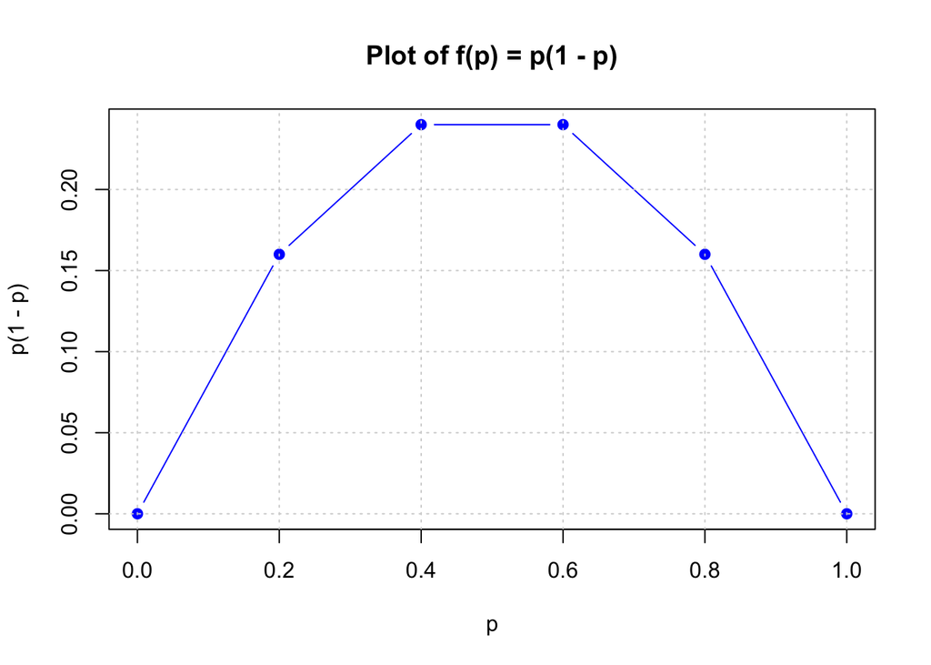

```r
f_p <- p * (1 - p)

plot(p, f_p, type = "b", col = "blue", pch = 19,
     xlab = "p", ylab = "p(1 - p)",
     main = "Plot of f(p) = p(1 - p)")

grid()
```

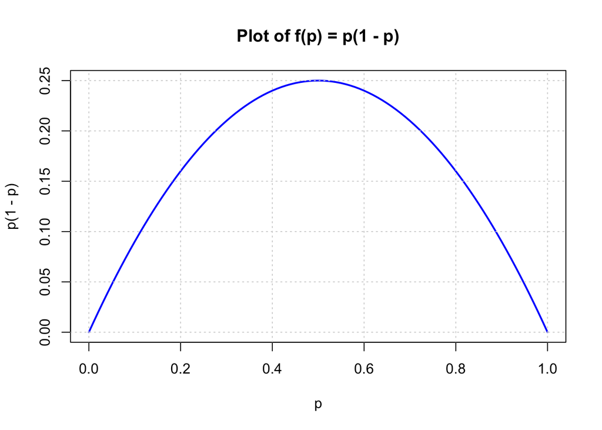

```r
p <- seq(from = 0, to = 1, by = 0.01)

f_p <- p * (1 - p)

plot(p, f_p, type = "l", col = "blue", lwd = 2,
     xlab = "p", ylab = "p(1 - p)",
     main = "Plot of f(p) = p(1 - p)")

grid()
```

# Exercise 5

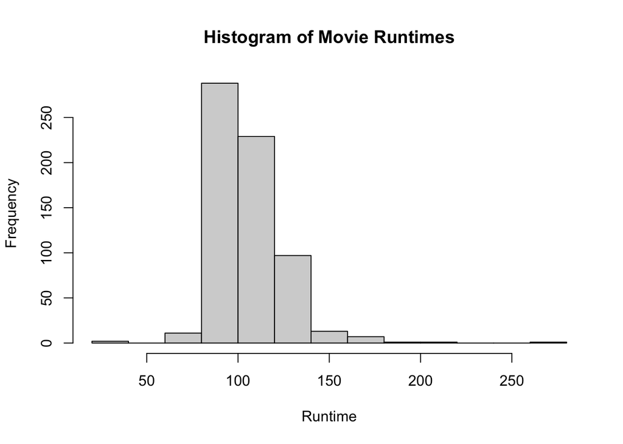

```r
movies <- read.csv("https://ericwfox.github.io/data/movies.csv")

hist(movies$runtime, main = "Histogram of Movie Runtimes",
     xlab = "Runtime",
     ylab = "Frequency")
```

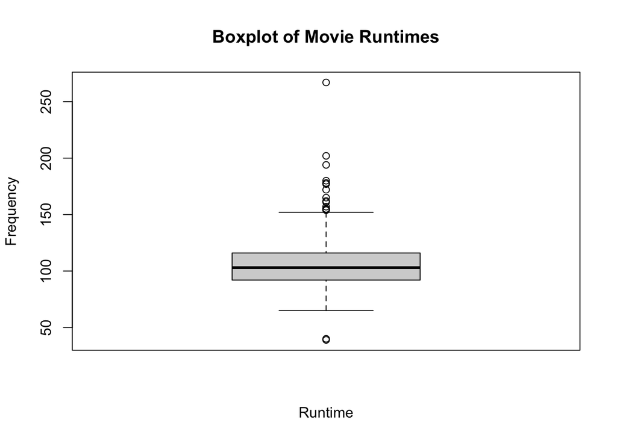

```r
boxplot(movies$runtime, main = "Boxplot of Movie Runtimes",
        xlab = "Runtime",
        ylab = "Frequency")
```

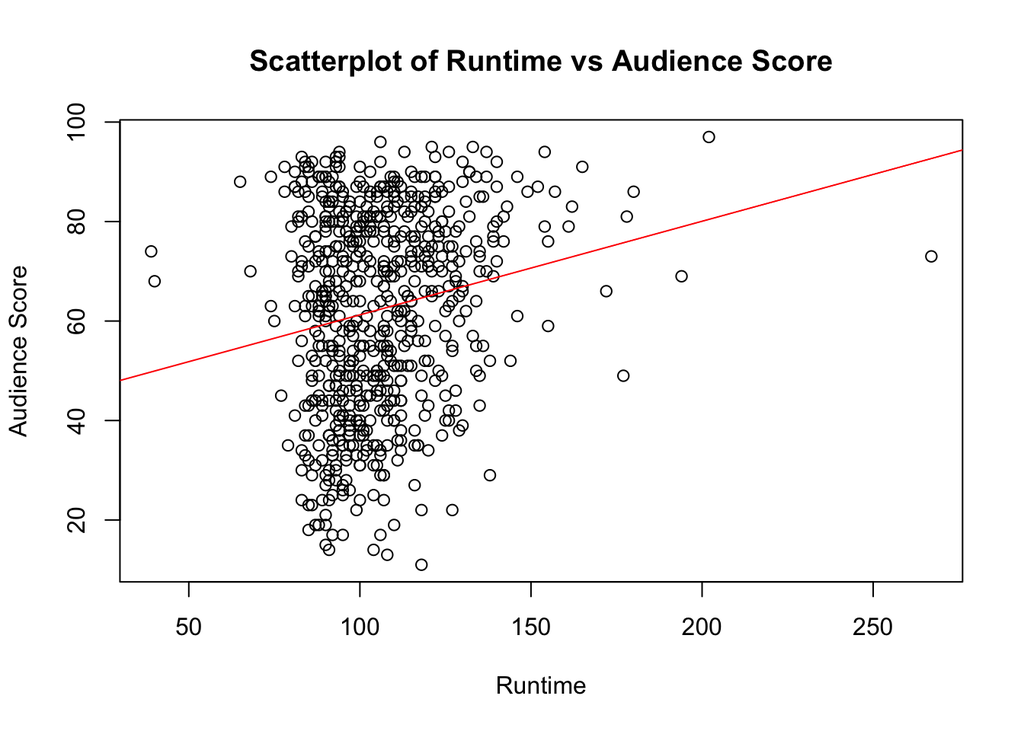

```r
plot(movies$runtime, movies$audience_score,
     main = "Scatterplot of Runtime vs Audience Score",
     xlab = "Runtime",
     ylab = "Audience Score")
model1 <- lm(movies$audience_score ~ movies$runtime)
abline(model1, col ="red")
```

2. The least squares line does seem to suggest a positive association between runtime and the audience score. The points of the data seem to be somewhat scattered around the least squares line. This would suggest possibly a weak or moderate association. It does seem a linear relationshi with some outliers past 150 minute runtime.

[figure not shown]

```r
movies$mpaa_rating <- factor(movies$mpaa_rating, levels = c("G", "PG", "PG-13", "R", "NC-17", "Unrated"))

boxplot(imdb_rating ~ mpaa_rating, data = movies,
        main = "IMDB Ratings by MPAA Rating",
        xlab = "MPAA Rating",
        ylab = "IMDB Rating",
        col = c("lightblue", "royalblue", "lightgreen", "green", "yellow", "orange"))
```